# Reproducible Research: Peer Assessment 1

Here we will analize data from an unspecified *personal activity monitoring device*. The device collects data at 5 minute intervals through out the day. The data consists of two months of data from an anonymous individual collected during the months of October and November, 2012 and include the number of steps taken in 5 minute intervals each day.

## Loading and preprocessing the data

Here we will load the csv data file from the provided zip file, `activity.zip`. As a first pass of preprocessig we will *naively* exclude missing values, we will refer to this as the *naive* or *remove NAs* method. We will revist this issue later in the imputation question.

```r
setwd("~/Desktop/data_science/05_reproduce/assign/RepData_PeerAssessment1/")
# extract and load activity.csv file from activity.zip
act_data <- read.csv(unz("activity.zip", "activity.csv"))
# note percentage of missing values
percent_na <- sum(is.na(act_data$steps))/length(act_data$steps) * 100  # percent missing
percent_na <- round(percent_na, 2)  # round to two desimal points
# Naively remove NAs for now
act_data.no_na <- act_data[!is.na(act_data$steps), ]  # remove NAs
```

## What is mean total number of steps taken per day?

It would be best to calculate the histogram of total steps as well as the mean and median.

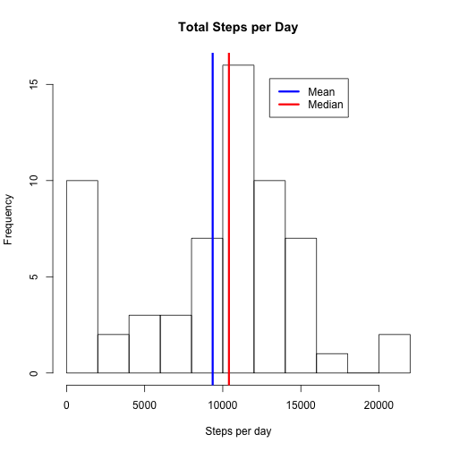

```r
# calculate the total number of steps for each day
steps_per_day = tapply(act_data.no_na$steps, act_data.no_na$date, sum)
steps_per_day[is.na(steps_per_day)] = 0  # set missing values to zero

# calculate the mean and median
mean_total_steps <- round(mean(steps_per_day))
median_total_steps <- round(median(steps_per_day))

# plot histogram with mean (blue), median (red)
hist(steps_per_day, breaks = 10, main = "Total Steps per Day", xlab = "Steps per day")
abline(v = mean_total_steps, lwd = 3, col = "blue")
abline(v = median_total_steps, lwd = 3, col = "red")
legend(13000, 15.3, c("Mean", "Median"), lwd = c(3, 3), col = c("blue", "red"))
```

The mean (blue) and median (red) of total number of steps per day, rounded to the nearest step, is 9354 and 1.0395 × 10<sup>4</sup>, respectively.

## What is the average daily activity pattern?

To do this we will again use the `tapply` function, but this time we will condition on the `interval` factor. This will calculate the mean number of steps in each five minuite interval for each day. In the plot below, the dailty average is plotted as the solid black line while the individual data points are plotted as low transparency points so as to give us an idea of their density per interval.

[figure not shown]

```r
library(scales)  # for alpha() transparancy

# calculate mean number of steps per interval
mean_steps_per_interval = tapply(act_data.no_na$steps, act_data.no_na$interval,
    mean)

# create the plot with mean number of steps and points
plot(act_data.no_na$interval, act_data.no_na$steps, col = alpha("light green",
    0.25), pch = 16, xlab = "Interval", ylab = "Number of Steps", main = "Average number of steps per 5-min interval (imputed)")
lines(names(mean_steps_per_interval), mean_steps_per_interval, lwd = 3, col = "black")
legend(83.67, 744.41, c("Avg. Steps"), lwd = c(3), col = c("black"))
```

```r
# what is the interval with the maximum average number of steps?
max_avg_steps <- round(max(mean_steps_per_interval), 2)
max_avg_steps_interval <- names(mean_steps_per_interval[mean_steps_per_interval ==
    max(mean_steps_per_interval)])
```

The 835 contained the maximum number of steps with 206.17 steps on avearge.

## Imputing missing values

Lets assume that missing values from each interval are missing **at random**, that is there is no underlying process that is biasing the missing data. We also note that only approximately 13.11% of our original sample is missing, meaning we likely still have a representative sample. Thus, it is reasonable to impute missing values in an inverval by taking a random sample from those observed in the same interval on other days.

```r
set.seed(12345)  # set random seed for replocation
missing_set <- act_data[is.na(act_data$steps), ]  # NAs samples to impute
non_missing_set <- act_data[!is.na(act_data$steps), ]  # observed samples

# interate through the missing_set, noting the interval for each iteraction,
# and taking a random sample from the non_missing_set and imputing that
# value into the original data frame act_data
for (i in row.names(missing_set)) {
    # note interval
    missing_interval = act_data[i, "interval"]
    # create a sample set for the missing interval
    sample_set <- non_missing_set[non_missing_set$interval == missing_interval,
        "steps"]
    # take sample
    samp <- sample(sample_set, size = 1, replace = TRUE)
    # impute value in data frame
    act_data[i, "steps"] = samp
}
```

After imputing, we should re-plot the total steps per day to observe any distributional changes.

[figure not shown]

```r
# calculate the total number of steps for each day
steps_per_day_imp = tapply(act_data$steps, act_data$date, sum)

# calculate the mean and median
mean_total_steps_imp <- round(mean(steps_per_day_imp))
median_total_steps_imp <- round(median(steps_per_day_imp))

# plot histogram with mean (blue), median (red)
hist(steps_per_day, breaks = 10, main = "Total Steps per Day (Imputed)", xlab = "Steps per day")
abline(v = mean_total_steps_imp, lwd = 3, col = "blue")
abline(v = median_total_steps_imp, lwd = 3, col = "red")
legend(13000, 15.3, c("Mean", "Median"), lwd = c(3, 3), col = c("blue", "red"))
```

The mean (blue) and median (red) of total number of steps per day, rounded to the nearest step, is 1.0744 × 10<sup>4</sup> and 1.0828 × 10<sup>4</sup>, respectively. We notice they are now much closer together than before.

At this point in might be prudent to replot our mean activity levels again to check to see if the reuslts have changed between our naive method, where we removed all NAs from the sample, and our new *random sample* imputation method we just performed.

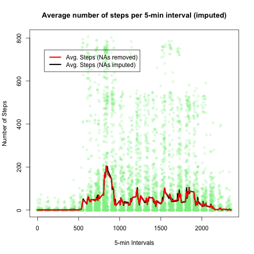

```r
# plot the activity levels again to see if there are any differences after
# random imputation
mean_steps_per_interval_imp <- tapply(act_data$steps, act_data$interval, mean)
plot(act_data$interval, act_data$steps, col = alpha("light green", 0.25), pch = 16,
    xlab = "5-min Intervals", ylab = "Number of Steps", main = "Average number of steps per 5-min interval (imputed)")
lines(names(mean_steps_per_interval_imp), mean_steps_per_interval_imp, lwd = 3,
    col = "black")
lines(names(mean_steps_per_interval), mean_steps_per_interval, lwd = 3, col = "red")
legend(83.67, 744.41, c("Avg. Steps (NAs removed)", "Avg. Steps (NAs imputed)"),
    lwd = c(3, 3), col = c("red", "black"))
```

Comparing the two averages above accross the intervals, we observe that there is not much difference in the means when comparing the NAs removed and NAs imputed methods. We observe that there may be some slight underestimation in some intervals in the NAs removed sample.

## Are there differences in activity patterns between weekdays and weekends?

Next, we'll separate the data into weekends and weekdays and calcualte the per step averages separately. Then we will plot them together with different colors.

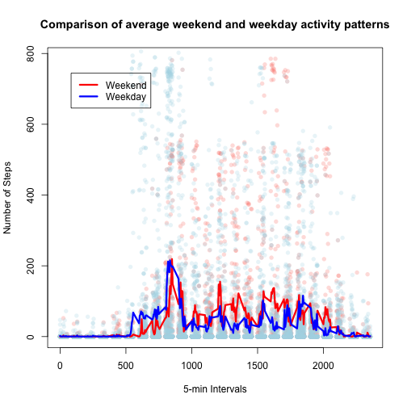

```r
act_data$dayOfWeek = weekdays(as.Date(act_data$date))  # create dayOfWeek factor
act_data$weekend = (act_data$dayOfWeek %in% c("Saturday", "Sunday"))  # create weekend factor
act_data_weekend = act_data[act_data$weekend == TRUE, ]  # weekend set
act_data_weekday = act_data[act_data$weekend == FALSE, ]  # weekday set

# calculate weekday and weekend means
mean_steps_per_interval_weekend = tapply(act_data_weekend$steps, act_data_weekend$interval,
    mean)
mean_steps_per_interval_weekday = tapply(act_data_weekday$steps, act_data_weekday$interval,
    mean)

# plot both the points
plot(act_data_weekend$interval, act_data_weekend$steps, col = alpha("salmon",
    0.25), pch = 16, main = "Comparison of average weekend and weekday activity patterns",
    xlab = "5-min Intervals", ylab = "Number of Steps")
points(act_data_weekday$interval, act_data_weekday$steps, col = alpha("light blue",
    0.25), pch = 16)

# plot the averages
lines(names(mean_steps_per_interval_weekend), mean_steps_per_interval_weekend,
    lwd = 3, col = "red")
lines(names(mean_steps_per_interval_weekday), mean_steps_per_interval_weekday,
    lwd = 3, col = "blue")

# add a legend for lines
legend(83.67, 744.41, c("Weekend", "Weekday"), lwd = c(3, 3), col = c("red",
    "blue"))
```

The two patterns are somewhat simmilar, but there are also some subltle differences. We can notice that on weekdays (blue), the average activity increases earlier than on weekends, consistent with a general trend of getting up earlier on weekdays. We can also notice that on weekend (red) the mid day average activity (between intervals 1200 and 1800) is higher, possibly due to extra curricular activies that cause people to move around more often. We also can notice that people are more active later into the night on weekends.

```r
cur_date <- date()
```

This document was last compiled Sat Jun 14 10:54:25 2014.